# RMarkdown Notes

Meryem Usta

## **About Myself**

My name is Meryem Usta. I graduated from Istanbul Technical University Mathematical Engineering in August 2017. I’m beginning MEF University Master of Big Data Analytics in September 2021.

I’m working at Garanti Technology as Data Engineer. I develop ETL pipeline and legal reports. I mainly use Oracle Data Integrator for data processing, SQL for analysis and Oracle Business Intelligence for reporting

I am interested in mathematics and software fields.I want to do professional work in the field of data analytics, which I am interested in, and to direct my career completely to the field of data science.

**Contact me** : [Linkedin](https://www.linkedin.com/in/meryemusta/)

## **UseR! Systematic Data Validation**

*Systematic data validation with the validate package*

If you try to make some logical assumption your data, you would manipulate it. You should clean or edit the data for appling statistical methods or using machine learning algorithms. R suply “validate” package for this process.

This process includes some steps:

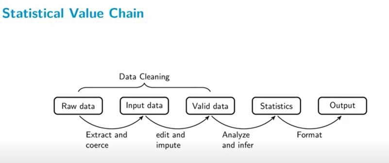

If you watch: [Click](https://www.youtube.com/watch?v=hb785sQt8tg&list=PL4IzsxWztPdnCC_kMCYKrd_t6cViMhBrD&index=2)

## **R-Post**

R is used in various fields such as banking, marketing sector. Some example of using R:

1. *Customer Segmentation*

When a product is to be marketed in banking, it is important to reach the right customer. Identifying the right customers saves time and money.Therefore, with some modeling methods, customers should be divided into groups and the target audience should be determined.

If you read more: [Click](https://data-flair.training/blogs/r-data-science-project-customer-segmentation/)

2. *Fraud Detection*

Millions of transactions take place in the bank every day. It is of great importance to determine whether these transactions are fraudulent.An algorithm is created thanks to the fraudulent and non-fraud transactions that have taken place so far and a probability of fraudulent transactions can be determined.

If you read more: [Click](https://blog.codecentric.de/en/2017/09/data-science-fraud-detection/)

3. *Social Media Analysis*

You have a product and need enchance your trend. If you make social media analtics, you find better channel to marketing products. You can analysize other products and determine your product’s customer segment and its price. Therefore, you can manage time and money.

If you read more: [Click](https://www.packtpub.com/product/learning-social-media-analytics-with-r/9781787127524)